# Principal Component Analysis - FIFA 2019 Data

# Data Dimension Reduction for ML modeling

The summary above indicates that PC1 through PC16 explain at least 80% of the variance of the goal keepers. This allows dimension reduction by more than half for ML modeling.

```r
# re-run prcomp with rank. argument to specify to have a max. of 16 PCs
pca_gk_16pc <- prcomp(df_gk_train[, 55:88], center = TRUE, scale. = TRUE, rank. = 16)
summary(pca_gk_16pc)
```

```
## Importance of first k=16 (out of 34) components:
##                           PC1    PC2     PC3    PC4     PC5     PC6     PC7
## Standard deviation     3.2441 1.8719 1.31565 1.2894 1.11204 1.07279 1.01624
## Proportion of Variance 0.3095 0.1031 0.05091 0.0489 0.03637 0.03385 0.03037
## Cumulative Proportion  0.3095 0.4126 0.46351 0.5124 0.54878 0.58263 0.61300
##                            PC8     PC9    PC10    PC11    PC12    PC13    PC14
## Standard deviation     0.99878 0.93904 0.89667 0.87210 0.84676 0.82584 0.80645
## Proportion of Variance 0.02934 0.02594 0.02365 0.02237 0.02109 0.02006 0.01913
## Cumulative Proportion  0.64234 0.66828 0.69193 0.71430 0.73539 0.75544 0.77457
##                           PC15   PC16
## Standard deviation     0.80002 0.7844
## Proportion of Variance 0.01882 0.0181
## Cumulative Proportion  0.79340 0.8115
```

```r
# Alternatively, re-run prcomp with tol set to .25 to automatically omit components if their standard deviations
# are less than or equal to tol times the standard deviation of the first component
pca_gk_13pc <- prcomp(df_gk_train[, 55:88], center = TRUE, scale. = TRUE, tol = .25)
summary(pca_gk_13pc)  # components 14 - 34 are omitted. PC 1 through PC 13 explained > 75% of the variance of the GK data.
```

```
## Importance of first k=13 (out of 34) components:
##                           PC1    PC2     PC3    PC4     PC5     PC6     PC7
## Standard deviation     3.2441 1.8719 1.31565 1.2894 1.11204 1.07279 1.01624
## Proportion of Variance 0.3095 0.1031 0.05091 0.0489 0.03637 0.03385 0.03037
## Cumulative Proportion  0.3095 0.4126 0.46351 0.5124 0.54878 0.58263 0.61300
##                            PC8     PC9    PC10    PC11    PC12    PC13
## Standard deviation     0.99878 0.93904 0.89667 0.87210 0.84676 0.82584
## Proportion of Variance 0.02934 0.02594 0.02365 0.02237 0.02109 0.02006
## Cumulative Proportion  0.64234 0.66828 0.69193 0.71430 0.73539 0.75544
```

# Discuss how well (or poorly) these new components and features represent the data

## visualization, using predict() with first 16 PC and new data

The new principal components created from the original features are difficult to understand as it is hard to understand how the components relate to any one of the skill ratings, which are meaningful in the world of soccer. However, conducting principal component analysis (PCA) provides an advantage in that each of the resultant principal components consists of a certain percent of loading from each of the 34 original features. Correlation matrix for the goalkeeper cluster shows that quite some skills are strongly correlated, thus PCA results indicates that the data dimension may be reduced from 34 components to 16 and still be able to explain more than 80% of variance in the group. Even though data dimension is reduced, not one skill rating/feature is completely left out. The disadvantage is that visualization in the new principal dimensions is hard to comprehend. Goalkeepers in the train data set are represented by circles in the data space (in the new principal component 1 and 2 dimensions), while those in the test set are represented by diamonds filled with a cross. In both train and test sets, goalkeepers with higher rank in international reputation are displayed in the bottom left quadrant of the plot. But it is hard to visualize what skill ratings they receive and why they are plotted in the bottom left of the chart.

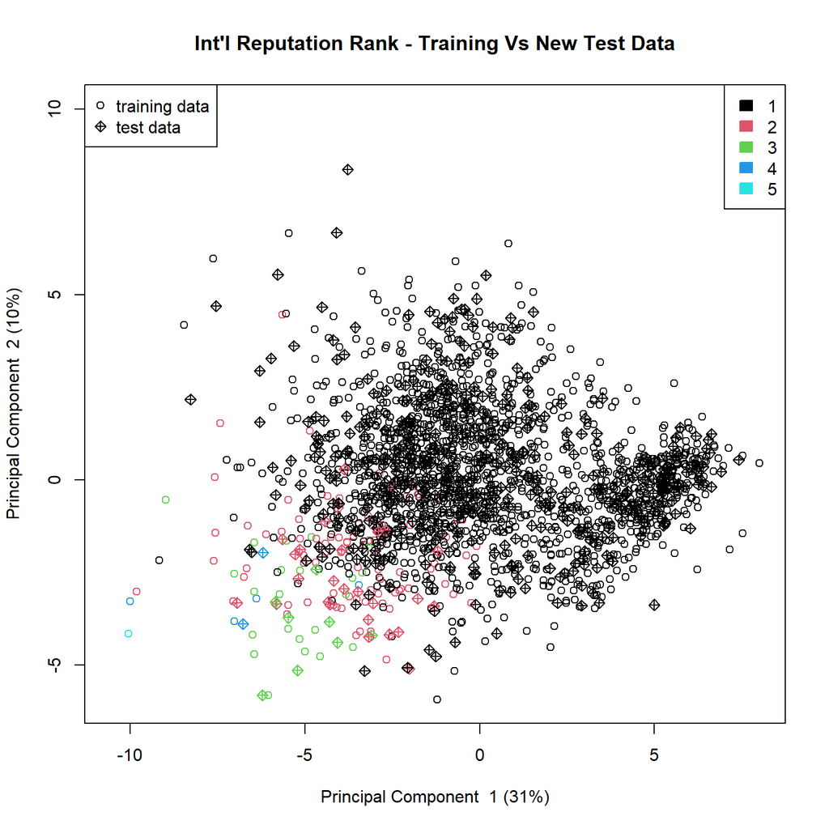

```r
pred <- predict(pca_gk_16pc, newdata = df_gk_test[ , 55:88])
expl.var <- round(pca_gk_16pc$sdev^2/sum(pca_gk_16pc$sdev^2)*100) # percent explained variance

# plot resultS
# International.Reputation
COLOR <- c(1:5)
PCH <- c(1, 9)
pc <- c(1:2)  # plot data in pc1 and pc2 dimensions
plot(pca_gk_16pc$x[,pc], col = COLOR[df_gk_train$International.Reputation], cex = PCH[1],
xlab = paste0("Principal Component  ", pc[1], " (", expl.var[pc[1]], "%)"),
ylab = paste0("Principal Component  ", pc[2], " (", expl.var[pc[2]], "%)"),
main = "Int'l Reputation Rank - Training Vs New Test Data"
)
# add results of new data
points(pred[, pc], col = COLOR[df_gk_test$International.Reputation], pch = PCH[2])
legend("topright", legend = levels(df_gk_test$International.Reputation), fill = COLOR, border = COLOR)
legend("topleft", legend = c("training data", "test data"), col = 1, pch = PCH)
```

## Selecting Original Features

Alternatively, one may select the original feature with highest loading from each of the first 16 PCs. The section below lists the top 4 original features (player skill ratings) in each of the first 16 principal components. Based on the list of variable loadings in each principal component, from PC 4, ShortPassing rating with the second highest loading will be selected, as LongPassing rating has already been selected for having the highest loading in PC 3. Similarly, from PC 8, SlidingTackle rating with the second highest loading will be selected, as Strength rating has already been selected for having the highest loading in PC 7. The advantage of using the original features from the data for data analysis or ML modeling is for easy understand for clients. However, the results will bear no representation of the original features that are left out from the model.

```r
# Top 4 original features that have the highest loadings in the first 16 principal components
print("Top 4 original features that have the highest loadings in the first 16 principal components:")
```

```
## [1] "Top 4 original features that have the highest loadings in the first 16 principal components:"
```

```r
for (i in 1:16) {
  contrib_i <- abs(pca_gk_16pc$rotation[,i])/sum(abs(pca_gk_16pc$rotation[,i]))
  print(paste("PC", i, sep = " "))
  print(head(contrib_i[order(-contrib_i)], n = 4L))
}
```

```
## [1] "PC 1"
##    Reactions   GKReflexes Acceleration  SprintSpeed
##   0.04085676   0.03976054   0.03970956   0.03966266
## [1] "PC 2"
##    GKHandling      GKDiving GKPositioning    GKReflexes
##    0.05578863    0.05393217    0.05375409    0.05297679
## [1] "PC 3"
##  LongPassing    ShotPower      Balance ShortPassing
##   0.06785778   0.06496354   0.06043396   0.05811630
## [1] "PC 4"
##  LongPassing ShortPassing      Jumping      Agility
##   0.08189425   0.07581314   0.06658246   0.05469199
## [1] "PC 5"
##        Curve   FKAccuracy ShortPassing     Crossing
##   0.09852551   0.09412735   0.06567044   0.05412444
## [1] "PC 6"
## Aggression  Penalties     Vision    Marking
## 0.10951906 0.08213025 0.07918917 0.07864367
## [1] "PC 7"
##       Strength StandingTackle  SlidingTackle        Balance
##     0.09868959     0.08545053     0.07610682     0.06751483
## [1] "PC 8"
##        Strength   SlidingTackle  StandingTackle HeadingAccuracy
##      0.10556074      0.08959212      0.08254972      0.05522706
## [1] "PC 9"
##    Marking   Strength Aggression     Vision
## 0.26507388 0.07488424 0.07468176 0.07101239
## [1] "PC 10"
##      Aggression HeadingAccuracy         Stamina        Crossing
##      0.10210062      0.09098487      0.08454480      0.07081583
## [1] "PC 11"
## HeadingAccuracy   SlidingTackle  StandingTackle       Composure
##      0.16023988      0.07704856      0.06877594      0.06585417
## [1] "PC 12"
##  ShotPower     Vision    Stamina FKAccuracy
## 0.13014551 0.11069757 0.06718613 0.05855708
## [1] "PC 13"
##    Agility    Balance  Penalties  Composure
## 0.07813664 0.06579827 0.05530312 0.05333511
## [1] "PC 14"
##  Dribbling    Stamina Aggression  Composure
## 0.13988384 0.07960841 0.06465156 0.05971293
## [1] "PC 15"
##   Strength  Composure  Dribbling FKAccuracy
## 0.11745545 0.06992481 0.06972830 0.06615002
## [1] "PC 16"
##      Vision BallControl  Aggression     Volleys
##  0.08492441  0.06506503  0.06366987  0.05851844
```

## Visualization with Original features (Skill Ratings)

Visualization with original features is much easier to understand. The following plot is created using two original features that contribute most to the variance of the goalkeeper data set, according to the PCA results. Visually, clients may relate to the information that there is a positive strong correlation (coefficient = 0.7220857) between Reactions Rating and GK Handling Rating. Additionally, the higher these ratings are the higher the player’s international reputation rank is, as shown by the colored dots that represent players who rank higher in international reputation.

```r
# calculate correlation coefficient
 cor(df_gk_train$Reactions, df_gk_train$GKHandling)
```

```
## [1] 0.7220857
```

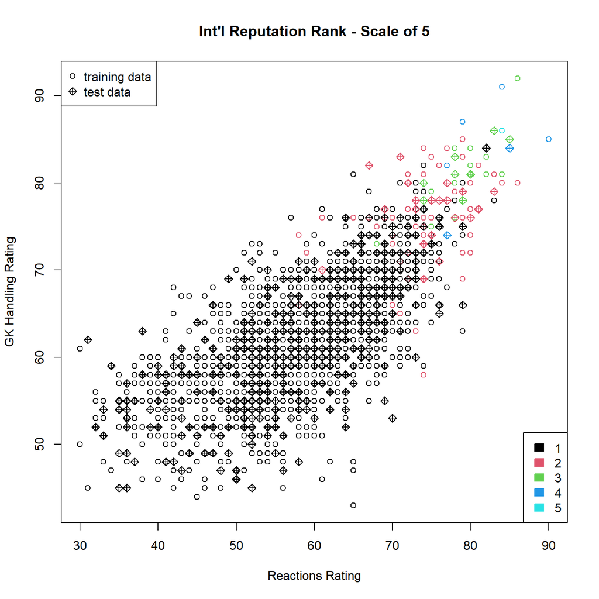

```r
# plot resultS in original features (first 2 features that explain the most variance)
# International.Reputation
COLOR <- c(1:5)
PCH <- c(1, 9)

plot(df_gk_train$Reactions, df_gk_train$GKHandling, col = COLOR[df_gk_train$International.Reputation], cex = PCH[1],
xlab = "Reactions Rating", ylab = "GK Handling Rating",
main = "Int'l Reputation Rank - Scale of 5"
)
# add results of new data
points(df_gk_test$Reactions, df_gk_test$GKHandling, col = COLOR[df_gk_test$International.Reputation], pch = PCH[2])
legend("bottomright", legend = levels(df_gk_test$International.Reputation), fill = COLOR, border = COLOR)
legend("topleft", legend = c("training data", "test data"), col = 1, pch = PCH)
```